# Telecom Churn Prediction

### Natália Faraj Murad

```
The objective of this project is predict behavior to retain customers. Analysing all relevant customer data can help to develop focused customer retention programs. The dataset was obtained from https://www.kaggle.com/mnassrib/telecom-churn-datasets. It contains information about the State, Area, Account, Type of plan of the customers, how much they spend on charges, the schedule they do more calls and others. Here these variables are explored in order to get insights about customer behavior, and Machine Learning Algorithms are used to predict if a customer will continue with its plan or not.
```

### Importing libraries

```python
#!pip install sweetviz
#!pip install missingno

import pandas as pd
import numpy as np
from numpy import loadtxt

import warnings
import sweetviz as sv
import matplotlib.pyplot as plt
import seaborn as sns
import missingno as missing
import random
import re
import sys
import joblib

from sklearn import feature_selection

from sklearn.preprocessing import StandardScaler
from sklearn.preprocessing import LabelEncoder
from sklearn.preprocessing import OneHotEncoder

from sklearn import model_selection
from sklearn.model_selection import train_test_split
from sklearn.model_selection import GridSearchCV
from sklearn.model_selection import KFold

from sklearn.linear_model import LogisticRegression
from sklearn.neighbors import KNeighborsClassifier
from sklearn.naive_bayes import GaussianNB
from sklearn.tree import DecisionTreeClassifier
from sklearn.svm import SVC
from sklearn.ensemble import RandomForestClassifier
from xgboost import XGBClassifier
from sklearn.ensemble import VotingClassifier

from sklearn import metrics
from sklearn.metrics import classification_report,confusion_matrix
from sklearn.metrics import f1_score, precision_score, recall_score, fbeta_score
from sklearn.metrics import accuracy_score

import matplotlib.ticker as mtick
from IPython.display import display

%matplotlib inline
color = sns.color_palette()
warnings.simplefilter(action = 'ignore', category = FutureWarning)
```

### Reading dataset

```python
df = pd.read_csv('projeto4_telecom_treino.csv')
```

```python
df.dtypes
```

```
Unnamed: 0                         int64
state                             object
account_length                     int64
area_code                         object
international_plan                object
voice_mail_plan                   object
number_vmail_messages              int64
total_day_minutes                float64
total_day_calls                    int64
total_day_charge                 float64
total_eve_minutes                float64
total_eve_calls                    int64
total_eve_charge                 float64
total_night_minutes              float64
total_night_calls                  int64
total_night_charge               float64
total_intl_minutes               float64
total_intl_calls                   int64
total_intl_charge                float64
number_customer_service_calls      int64
churn                             object
dtype: object
```

```python
df.head()
```

|  | Unnamed: 0 | state | account_length | area_code | international_plan | voice_mail_plan | number_vmail_messages | total_day_minutes | total_day_calls | total_day_charge | ... | total_eve_calls | total_eve_charge | total_night_minutes | total_night_calls | total_night_charge | total_intl_minutes | total_intl_calls | total_intl_charge | number_customer_service_calls | churn |
| --- | --- | --- | --- | --- | --- | --- | --- | --- | --- | --- | --- | --- | --- | --- | --- | --- | --- | --- | --- | --- | --- |
| 0 | 1 | KS | 128 | area_code_415 | no | yes | 25 | 265.1 | 110 | 45.07 | ... | 99 | 16.78 | 244.7 | 91 | 11.01 | 10.0 | 3 | 2.70 | 1 | no |
| 1 | 2 | OH | 107 | area_code_415 | no | yes | 26 | 161.6 | 123 | 27.47 | ... | 103 | 16.62 | 254.4 | 103 | 11.45 | 13.7 | 3 | 3.70 | 1 | no |
| 2 | 3 | NJ | 137 | area_code_415 | no | no | 0 | 243.4 | 114 | 41.38 | ... | 110 | 10.30 | 162.6 | 104 | 7.32 | 12.2 | 5 | 3.29 | 0 | no |
| 3 | 4 | OH | 84 | area_code_408 | yes | no | 0 | 299.4 | 71 | 50.90 | ... | 88 | 5.26 | 196.9 | 89 | 8.86 | 6.6 | 7 | 1.78 | 2 | no |
| 4 | 5 | OK | 75 | area_code_415 | yes | no | 0 | 166.7 | 113 | 28.34 | ... | 122 | 12.61 | 186.9 | 121 | 8.41 | 10.1 | 3 | 2.73 | 3 | no |

5 rows × 21 columns

### Data exploration

```python
df['international_plan'].value_counts() # How many customers have an international plan
```

```
no     3010
yes     323
Name: international_plan, dtype: int64
```

```python
df['voice_mail_plan'].value_counts()
```

```
no     2411
yes     922
Name: voice_mail_plan, dtype: int64
```

```python
eda = sv.analyze(source = df,
                target_feat = 'churn')
```

```python
eda.show_notebook()
```

[interactive chart not shown]

### Distribution of Numeric Variables & Churn

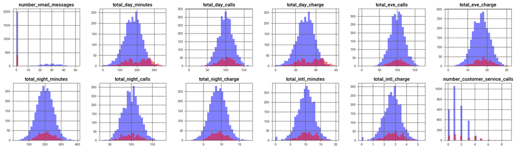

```python
pred_vars = ['number_vmail_messages', 'total_day_minutes', 'total_day_calls', 'total_day_charge',
             'total_eve_calls', 'total_eve_charge', 'total_night_minutes', 'total_night_calls',
             'total_night_charge', 'total_intl_minutes',
             'total_intl_charge', 'number_customer_service_calls']

fig, ax = plt.subplots(2, 6, figsize=(22, 6));
df[df.churn == 'no'][pred_vars].hist( bins=30, color="blue", alpha=0.5, ax=ax);
df[df.churn == 'yes'][pred_vars].hist( bins=30, color="red", alpha=0.5, ax=ax);
```

People that spend more minutes during the day and have higher total day charge tends to churn more. Maybe they need a day offer. People that do not use Voice Messages has high churn.

### People that cancel profile

```python
# Color palette
myred='#E74C3C'
myblue='#2E86C1'
mygreen='#28B463'
cols= [myblue, myred, mygreen]
```

### Churn Rate

```python
# percentage of churn
df['churn'].replace(['yes', 'no'],[1,0]).sum()/df['churn'].count()
```

```
0.14491449144914492
```

The churn rate is 14.49%

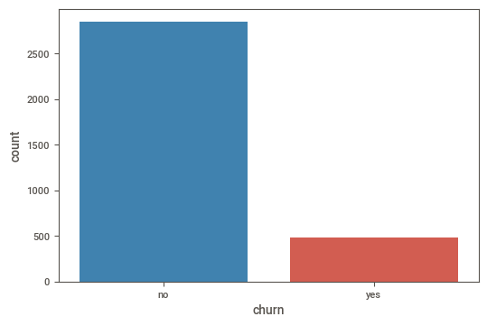

```python
sns.countplot(data=df,x='churn',palette=cols);
```

### Numeric Variables Colinearity

```python
df_num=df[['total_day_minutes', 'total_day_calls', 'total_day_charge', 'total_eve_calls',
          'total_eve_charge', 'total_night_minutes', 'total_night_calls', 'total_night_charge',
          'total_intl_minutes', 'total_intl_charge']]
#df_num
```

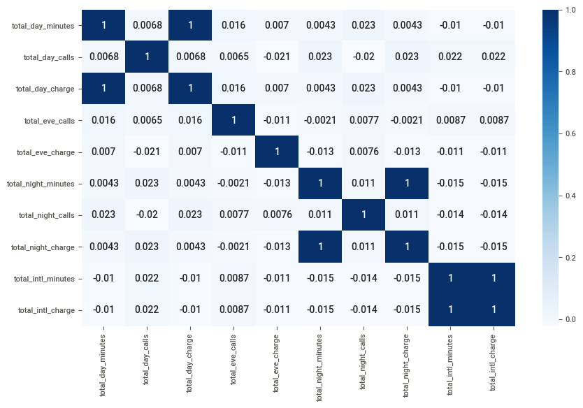

```python
plt.figure(figsize=(10, 6))
sns.heatmap(df_num.corr(),annot = True,
            cmap='Blues');
```

Colinearity

*total_night_charge* and *total_night_minutes*

*total_day_charge* and *total_day_minutes*

*total_intl_charge* and *total_intl_minutes*

It is expected because if the person uses more minutes, they will need to charge more.

#### Churn vs number of service calls

```python
df['churn1']=df.churn.replace(['yes', 'no'],[1,0])
df_plot = df.groupby('number_customer_service_calls').churn1.mean().reset_index()
df.drop('churn1', axis=1, inplace = True)
df_plot
```

|  | number_customer_service_calls | churn1 |
| --- | --- | --- |
| 0 | 0 | 0.131994 |
| 1 | 1 | 0.103302 |
| 2 | 2 | 0.114625 |
| 3 | 3 | 0.102564 |
| 4 | 4 | 0.457831 |
| 5 | 5 | 0.606061 |
| 6 | 6 | 0.636364 |
| 7 | 7 | 0.555556 |
| 8 | 8 | 0.500000 |
| 9 | 9 | 1.000000 |

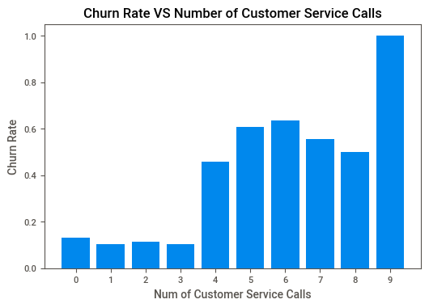

```python
#Number of Service calls vs churn
x =df_plot['number_customer_service_calls']
y=df_plot['churn1']
plt.bar(x,y);
plt.title('Churn Rate VS Number of Customer Service Calls');
plt.xlabel('Num of Customer Service Calls');
plt.ylabel('Churn Rate');
plt.xticks(x, (0,1,2,3,4,5,6,7,8,9));
```

#### Total intl charge vs Churn

```
churn
no     2.743404
yes    2.889545
Name: total_intl_charge, dtype: float64
```

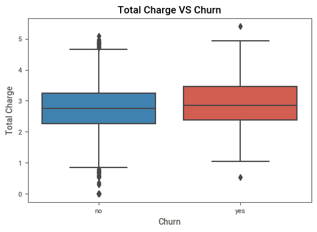

```python
cols= [myblue, myred, mygreen]
sns.boxplot(x="churn", y="total_intl_charge", data=df, palette=cols);
plt.title('Total Charge VS Churn');
plt.xlabel('Churn');
plt.ylabel('Total Charge');
df.groupby(['churn'])['total_intl_charge'].mean()
```

No significant differences.

## Data preprocessing

```python
df["state"].nunique()
```

```
51
```

### Droppping not important variables

```python
# Drop not important vars
df.drop(['Unnamed: 0', 'state'], axis = 1, inplace = True)
```

```python
#df.head()
```

```python
df.isnull().sum()
df.isna().any()
```

```
account_length                   False
area_code                        False
international_plan               False
voice_mail_plan                  False
number_vmail_messages            False
total_day_minutes                False
total_day_calls                  False
total_day_charge                 False
total_eve_minutes                False
total_eve_calls                  False
total_eve_charge                 False
total_night_minutes              False
total_night_calls                False
total_night_charge               False
total_intl_minutes               False
total_intl_calls                 False
total_intl_charge                False
number_customer_service_calls    False
churn                            False
dtype: bool
```

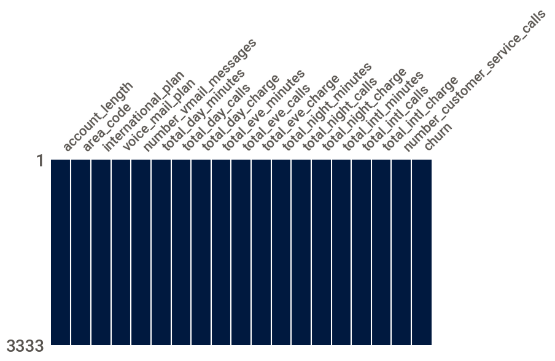

```python
missing.matrix(df, figsize = (8,4), color = (0, 0.1, 0.25), sparkline = False);
```

It does not present null values

### Grouping Categories

```python
df['churn'].value_counts()
```

```
no     2850
yes     483
Name: churn, dtype: int64
```

### Changing yes and no to 0 and 1

```python
##Substituindo a variável sexo para 0 e 1

le = LabelEncoder()

df['international_plan'] = le.fit_transform(df['international_plan'])
df['voice_mail_plan'] = le.fit_transform(df['voice_mail_plan'])
df['churn'] = le.fit_transform(df['churn'])
```

```python
df.head(10)
```

|  | account_length | area_code | international_plan | voice_mail_plan | number_vmail_messages | total_day_minutes | total_day_calls | total_day_charge | total_eve_minutes | total_eve_calls | total_eve_charge | total_night_minutes | total_night_calls | total_night_charge | total_intl_minutes | total_intl_calls | total_intl_charge | number_customer_service_calls | churn |
| --- | --- | --- | --- | --- | --- | --- | --- | --- | --- | --- | --- | --- | --- | --- | --- | --- | --- | --- | --- |
| 0 | 128 | area_code_415 | 0 | 1 | 25 | 265.1 | 110 | 45.07 | 197.4 | 99 | 16.78 | 244.7 | 91 | 11.01 | 10.0 | 3 | 2.70 | 1 | 0 |
| 1 | 107 | area_code_415 | 0 | 1 | 26 | 161.6 | 123 | 27.47 | 195.5 | 103 | 16.62 | 254.4 | 103 | 11.45 | 13.7 | 3 | 3.70 | 1 | 0 |
| 2 | 137 | area_code_415 | 0 | 0 | 0 | 243.4 | 114 | 41.38 | 121.2 | 110 | 10.30 | 162.6 | 104 | 7.32 | 12.2 | 5 | 3.29 | 0 | 0 |
| 3 | 84 | area_code_408 | 1 | 0 | 0 | 299.4 | 71 | 50.90 | 61.9 | 88 | 5.26 | 196.9 | 89 | 8.86 | 6.6 | 7 | 1.78 | 2 | 0 |
| 4 | 75 | area_code_415 | 1 | 0 | 0 | 166.7 | 113 | 28.34 | 148.3 | 122 | 12.61 | 186.9 | 121 | 8.41 | 10.1 | 3 | 2.73 | 3 | 0 |
| 5 | 118 | area_code_510 | 1 | 0 | 0 | 223.4 | 98 | 37.98 | 220.6 | 101 | 18.75 | 203.9 | 118 | 9.18 | 6.3 | 6 | 1.70 | 0 | 0 |
| 6 | 121 | area_code_510 | 0 | 1 | 24 | 218.2 | 88 | 37.09 | 348.5 | 108 | 29.62 | 212.6 | 118 | 9.57 | 7.5 | 7 | 2.03 | 3 | 0 |
| 7 | 147 | area_code_415 | 1 | 0 | 0 | 157.0 | 79 | 26.69 | 103.1 | 94 | 8.76 | 211.8 | 96 | 9.53 | 7.1 | 6 | 1.92 | 0 | 0 |
| 8 | 117 | area_code_408 | 0 | 0 | 0 | 184.5 | 97 | 31.37 | 351.6 | 80 | 29.89 | 215.8 | 90 | 9.71 | 8.7 | 4 | 2.35 | 1 | 0 |
| 9 | 141 | area_code_415 | 1 | 1 | 37 | 258.6 | 84 | 43.96 | 222.0 | 111 | 18.87 | 326.4 | 97 | 14.69 | 11.2 | 5 | 3.02 | 0 | 0 |

### Controlling the scale of continue variables - padronization

```python
scaler = StandardScaler()
df_final = df

num_vars = [ 'total_day_calls', 'total_day_charge',
             'total_eve_calls', 'total_eve_charge', 'total_night_calls',
             'total_night_charge', 'total_intl_charge']
df_final[num_vars] = scaler.fit_transform(df_final[num_vars])
df_final[num_vars]
```

[output not shown]

### Categorize continue variables

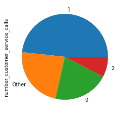

```python
def groupcat(x):
    if x == 0:
        return '0'
    elif x >= 1 | x <= 3:
        return '1'
    elif x >= 4 | x <= 6:
        return '2'
    else:
        return 'Other'

df_final['number_customer_service_calls'] = df_final['number_customer_service_calls'].apply(groupcat)
df_final['number_customer_service_calls'].value_counts().plot(kind = 'pie');
```

This step is useful to improve just for the Decision Tree Classifier Model.

```python
#df['number_vmail_messages'].value_counts()
```

```python
df_final[df_final['number_vmail_messages'] > 0]['number_vmail_messages'].describe()
```

```
count    922.000000
mean      29.277657
std        7.559027
min        4.000000
25%       24.000000
50%       29.000000
75%       34.000000
max       51.000000
Name: number_vmail_messages, dtype: float64
```

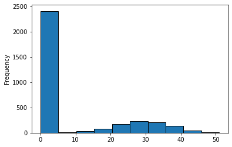

```python
# Categorizing vars with well defined concentration of numbers
df_final['number_vmail_messages'].plot(kind = 'hist', edgecolor = 'black');
```

```python
def categorizing(x):
    if x == 0:
        return 0
    elif x < 24:
        return 1
    elif x < 29:
        return 2
    else:
        return 3

df_final['number_vmail_messages'] = df_final['number_vmail_messages'].apply(categorizing)
df_final.head()
```

|  | account_length | area_code | international_plan | voice_mail_plan | number_vmail_messages | total_day_minutes | total_day_calls | total_day_charge | total_eve_minutes | total_eve_calls | total_eve_charge | total_night_minutes | total_night_calls | total_night_charge | total_intl_minutes | total_intl_calls | total_intl_charge | number_customer_service_calls | churn |
| --- | --- | --- | --- | --- | --- | --- | --- | --- | --- | --- | --- | --- | --- | --- | --- | --- | --- | --- | --- |
| 0 | 128 | area_code_415 | 0 | 1 | 2 | 265.1 | 0.476643 | 1.567036 | 197.4 | -0.055940 | -0.070427 | 244.7 | -0.465494 | 0.866029 | 10.0 | 3 | -0.085690 | 1 | 0 |
| 1 | 107 | area_code_415 | 0 | 1 | 2 | 161.6 | 1.124503 | -0.334013 | 195.5 | 0.144867 | -0.107549 | 254.4 | 0.147825 | 1.059390 | 13.7 | 3 | 1.241169 | 1 | 0 |
| 2 | 137 | area_code_415 | 0 | 0 | 0 | 243.4 | 0.675985 | 1.168464 | 121.2 | 0.496279 | -1.573900 | 162.6 | 0.198935 | -0.755571 | 12.2 | 5 | 0.697156 | 0 | 0 |
| 3 | 84 | area_code_408 | 1 | 0 | 0 | 299.4 | -1.466936 | 2.196759 | 61.9 | -0.608159 | -2.743268 | 196.9 | -0.567714 | -0.078806 | 6.6 | 7 | -1.306401 | Other | 0 |
| 4 | 75 | area_code_415 | 1 | 0 | 0 | 166.7 | 0.626149 | -0.240041 | 148.3 | 1.098699 | -1.037939 | 186.9 | 1.067803 | -0.276562 | 10.1 | 3 | -0.045885 | 1 | 0 |

### Dummy Variables

```python
vars_cat = ['number_vmail_messages', 'number_customer_service_calls', 'area_code']
df_final = pd.get_dummies(df_final, columns = vars_cat, drop_first = True)
```

### Split train & test datasets

```python
# Split train and test
X = df_final.loc[:, df_final.columns != 'churn']
y = df_final['churn']
X_train, X_test, y_train, y_test  = train_test_split(X, y, test_size = 0.20, random_state = 1)
```

### Training Several Baseline Models

```python
models = []
models.append(('Logistic Regression', LogisticRegression(solver='liblinear',
                                                         class_weight='balanced')))
models.append(('SVC', SVC(kernel = 'linear')))
models.append(('Kernel SVM', SVC(kernel = 'rbf')))
models.append(('KNN', KNeighborsClassifier(n_neighbors = 5, metric = 'minkowski', p = 2)))
models.append(('Gaussian NB', GaussianNB()))
models.append(('Decision Tree Classifier',
               DecisionTreeClassifier(criterion = 'entropy', random_state = 0)))
models.append(('Random Forest', RandomForestClassifier(
    n_estimators=100, criterion = 'entropy')))
#Evaluating Model Results:
acc_results = []
auc_results = []
names = []
# set table to table to populate with performance results
col = ['Algorithm', 'ROC AUC Mean', 'ROC AUC STD',
       'Accuracy Mean', 'Accuracy STD']
model_results = pd.DataFrame(columns=col)
i = 0
# Evaluate each model using k-fold cross-validation:
for name, model in models:
    kfold = model_selection.KFold(
        n_splits=10, random_state=0)

    # accuracy scoring:
    cv_acc_results = model_selection.cross_val_score(
    model, X_train, y_train, cv=kfold, scoring='accuracy')

    # roc_auc scoring:
    cv_auc_results = model_selection.cross_val_score(
    model, X_train, y_train, cv=kfold, scoring='roc_auc')
    acc_results.append(cv_acc_results)
    auc_results.append(cv_auc_results)
    names.append(name)
    model_results.loc[i] = [name,
                            round(cv_auc_results.mean()*100, 2),
                            round(cv_auc_results.std()*100, 2),
                            round(cv_acc_results.mean()*100, 2),
                            round(cv_acc_results.std()*100, 2)
                            ]
    i += 1

model_results.sort_values(by=['ROC AUC Mean'], ascending=False)
```

|  | Algorithm | ROC AUC Mean | ROC AUC STD | Accuracy Mean | Accuracy STD |
| --- | --- | --- | --- | --- | --- |
| 6 | Random Forest | 90.48 | 4.42 | 94.45 | 2.31 |
| 0 | Logistic Regression | 85.96 | 3.38 | 84.55 | 2.36 |
| 1 | SVC | 85.79 | 3.37 | 85.48 | 2.38 |
| 4 | Gaussian NB | 84.60 | 3.11 | 87.40 | 1.73 |
| 5 | Decision Tree Classifier | 83.58 | 4.83 | 91.33 | 2.13 |
| 2 | Kernel SVM | 73.58 | 4.49 | 85.56 | 2.66 |
| 3 | KNN | 65.36 | 5.35 | 86.46 | 2.21 |

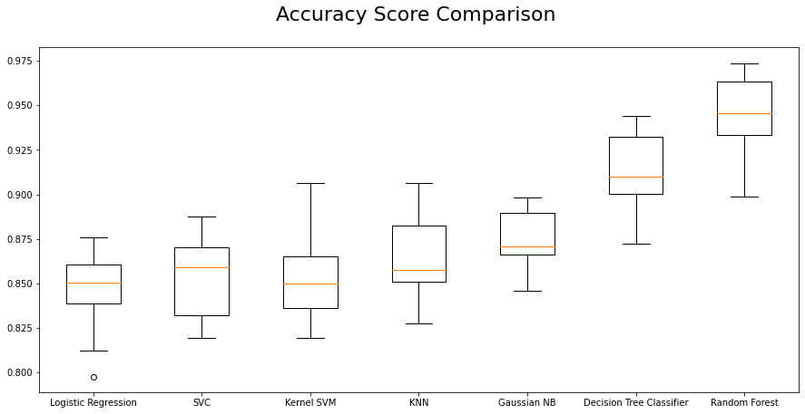

```python
fig = plt.figure(figsize=(15, 7))
ax = fig.add_subplot(111)
plt.boxplot(acc_results)
ax.set_xticklabels(names)
plt.title('Accuracy Score Comparison \n',
fontsize = "22", fontfamily = "sans-serif")
plt.xticks(rotation=0, horizontalalignment="center")
plt.yticks(rotation=0, horizontalalignment="right")
plt.show()
```

Random Forest presented a better performance

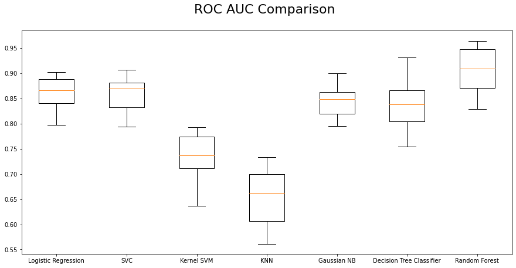

```python
fig = plt.figure(figsize=(15, 7))
ax = fig.add_subplot(111)
plt.boxplot(auc_results)
ax.set_xticklabels(names)
plt.title('ROC AUC Comparison \n',horizontalalignment="center", fontstyle = "normal", fontsize = "22",
fontfamily = "sans-serif")
plt.xticks(rotation=0, horizontalalignment="center")
plt.yticks(rotation=0, horizontalalignment="right")
plt.show()
```

### Decision Tree Classifier

```python
# create model using DecisionTree Classifier and fit training data
from sklearn.tree import DecisionTreeClassifier
dt_model = DecisionTreeClassifier()
dt_model.fit(X_train, y_train)
```

```
DecisionTreeClassifier()
```

```python
# create prediction
dt_pred = dt_model.predict(X_test)
dt_pred[0:5]
```

```
array([0, 0, 0, 0, 0])
```

```python
# Evaluating the prediction model
metrics.accuracy_score(y_test, dt_pred)
```

```
0.9010494752623688
```

#### Decision Tree Accuracy: 90%

### KNN

```python
knn = KNeighborsClassifier()
knn.fit(X_train, y_train)
```

```
KNeighborsClassifier()
```

```python
result_knn = knn.predict(X_test)
print (pd.crosstab(y_test,result_knn, rownames=['Real'], colnames=['Predicted'], margins=True))
```

```
Predicted    0   1  All
Real
0          546  23  569
1           64  34   98
All        610  57  667
```

```python
error = []

# Calculating error for K values between 1 and 40
for i in range(1, 40):
    knn = KNeighborsClassifier(n_neighbors=i)
    knn.fit(X_train, y_train)
    pred_i = knn.predict(X_test)
    error.append(np.mean(pred_i != y_test))
```

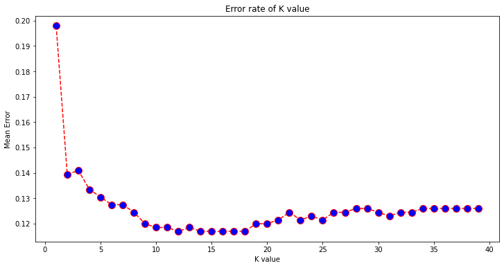

```python
# Plot of Mean Error vs Number of Neighbors
plt.figure(figsize=(12, 6))
plt.plot(range(1, 40), error, color='red', linestyle='dashed', marker='o',
         markerfacecolor='blue', markersize=10)
plt.title('Error rate of K value')
plt.xlabel('K value')
plt.ylabel('Mean Error')
```

```python
knn = KNeighborsClassifier(n_neighbors=15)
knn.fit(X_train, y_train)
```

```
KNeighborsClassifier(n_neighbors=15)
```

```python
result_knn = knn.predict(X_test)
print (pd.crosstab(y_test,result_knn, rownames=['Real'], colnames=['Predicted'], margins=True))
```

```
Predicted    0   1  All
Real
0          566   3  569
1           75  23   98
All        641  26  667
```

```python
print(classification_report(y_test, result_knn))
```

```
              precision    recall  f1-score   support

           0       0.88      0.99      0.94       569
           1       0.88      0.23      0.37        98

    accuracy                           0.88       667
   macro avg       0.88      0.61      0.65       667
weighted avg       0.88      0.88      0.85       667
```

#### KNN Model Accuracy: 88%

### Random Forest

#### Optimal Number of Trees

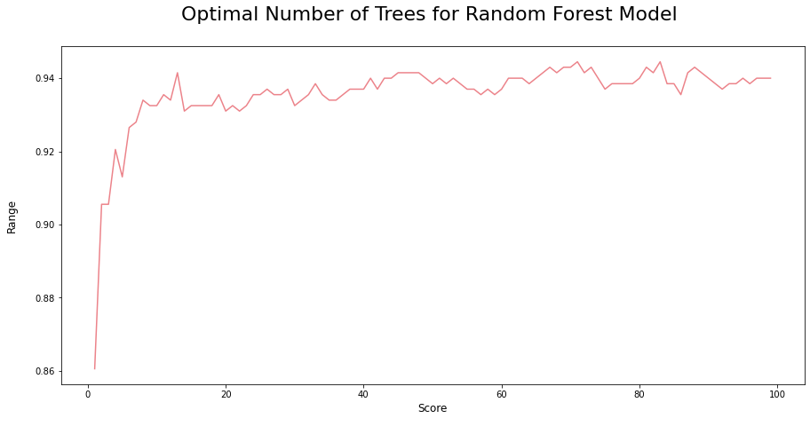

```python
score_array = []
for each in range(1,100):
    rf_loop = RandomForestClassifier(
n_estimators = each, random_state = 1)
    rf_loop.fit(X_train,y_train)
    score_array.append(rf_loop.score(X_test,y_test))

fig = plt.figure(figsize=(15, 7))
plt.plot(range(1,100),score_array, color = '#ec838a')
plt.ylabel('Range\n',horizontalalignment="center",
fontstyle = "normal", fontsize = "large",
fontfamily = "sans-serif")
plt.xlabel('Score\n',horizontalalignment="center",
fontstyle = "normal", fontsize = "large",
fontfamily = "sans-serif")
plt.title('Optimal Number of Trees for Random Forest Model \n',horizontalalignment="center", fontstyle = "normal", fontsize = "22", fontfamily = "sans-serif")
plt.xticks(rotation=0, horizontalalignment="center")
plt.yticks(rotation=0, horizontalalignment="right")
plt.show()
```

```python
# Model with 81 decision trees
rf = RandomForestClassifier (n_estimators = 81, random_state = 42)
# Training model
rf.fit (X_train, y_train);
```

```python
# Predictions with test data
y_rf = rf.predict(X_test)
print (pd.crosstab(y_test,y_rf, rownames=['Real'], colnames=['Predicted'], margins=True))
```

```
Predicted    0   1  All
Real
0          565   4  569
1           31  67   98
All        596  71  667
```

```python
print(classification_report(y_test, y_rf))
```

```
              precision    recall  f1-score   support

           0       0.95      0.99      0.97       569
           1       0.94      0.68      0.79        98

    accuracy                           0.95       667
   macro avg       0.95      0.84      0.88       667
weighted avg       0.95      0.95      0.94       667
```

#### Random Forest Accuracy: 95%

```python
# Feature Importance
rf.feature_importances_

feature_importances = pd.DataFrame(rf.feature_importances_, index = X_train.columns, columns=['importance']).sort_values('importance',ascending=False)
feature_importances
```

|  | importance |
| --- | --- |
| total_day_charge | 0.140958 |
| total_day_minutes | 0.126932 |
| number_customer_service_calls_2 | 0.091497 |
| international_plan | 0.076248 |
| total_eve_minutes | 0.068470 |
| total_eve_charge | 0.064455 |
| total_intl_charge | 0.048407 |
| total_intl_calls | 0.048220 |
| total_intl_minutes | 0.046710 |
| total_night_charge | 0.042940 |
| total_night_minutes | 0.040504 |
| total_day_calls | 0.038503 |
| total_eve_calls | 0.032753 |
| total_night_calls | 0.032265 |
| account_length | 0.031946 |
| voice_mail_plan | 0.028626 |
| number_customer_service_calls_1 | 0.009869 |
| number_vmail_messages_3 | 0.007155 |
| area_code_area_code_415 | 0.005570 |
| number_customer_service_calls_Other | 0.005253 |
| area_code_area_code_510 | 0.005033 |
| number_vmail_messages_2 | 0.004082 |
| number_vmail_messages_1 | 0.003601 |

### XGBoost

```python
# Adjusting model with training data
xgb = XGBClassifier()
xgb.fit(X_train, y_train)
```

```
[19:03:58] WARNING: ../src/learner.cc:1095: Starting in XGBoost 1.3.0, the default evaluation metric used with the objective 'binary:logistic' was changed from 'error' to 'logloss'. Explicitly set eval_metric if you'd like to restore the old behavior.
```

```
XGBClassifier(base_score=0.5, booster='gbtree', colsample_bylevel=1,
              colsample_bynode=1, colsample_bytree=1, gamma=0, gpu_id=-1,
              importance_type='gain', interaction_constraints='',
              learning_rate=0.300000012, max_delta_step=0, max_depth=6,
              min_child_weight=1, missing=nan, monotone_constraints='()',
              n_estimators=100, n_jobs=8, num_parallel_tree=1, random_state=0,
              reg_alpha=0, reg_lambda=1, scale_pos_weight=1, subsample=1,
              tree_method='exact', validate_parameters=1, verbosity=None)
```

```python
# Predictions with test set
predict_xgb = xgb.predict(X_test)
print (pd.crosstab(y_test,predict_xgb, rownames=['Real'], colnames=['Predicted'], margins=True))
```

```
Predicted    0   1  All
Real
0          564   5  569
1           26  72   98
All        590  77  667
```

```python
print(classification_report(y_test, predict_xgb))
```

```
              precision    recall  f1-score   support

           0       0.96      0.99      0.97       569
           1       0.94      0.73      0.82        98

    accuracy                           0.95       667
   macro avg       0.95      0.86      0.90       667
weighted avg       0.95      0.95      0.95       667
```

#### XGBoost Accuracy: 95%

## Voting Classifier

```python
# Voting Classifier with soft voting
vot = VotingClassifier(estimators=[('rf', rf),('xgb',xgb)], voting='soft')
vot = vot.fit(X_train,y_train)
```

```
[19:04:12] WARNING: ../src/learner.cc:1095: Starting in XGBoost 1.3.0, the default evaluation metric used with the objective 'binary:logistic' was changed from 'error' to 'logloss'. Explicitly set eval_metric if you'd like to restore the old behavior.
```

```python
y_predicted = vot.predict(X_test)
print (pd.crosstab(y_test,y_predicted, rownames=['Real'], colnames=['Predicted'], margins=True))
```

```
Predicted    0   1  All
Real
0          564   5  569
1           25  73   98
All        589  78  667
```

```python
print(classification_report(y_test, y_predicted))
```

```
              precision    recall  f1-score   support

           0       0.96      0.99      0.97       569
           1       0.94      0.74      0.83        98

    accuracy                           0.96       667
   macro avg       0.95      0.87      0.90       667
weighted avg       0.95      0.96      0.95       667
```

```python
# Churn Probability
df['proba'] = vot.predict_proba(df_final[X_train.columns])[:,1]
df[['proba']]
```

[output not shown]

#### Voting Accuracy 96%

## Searching Best Parameters

```python
# Grid of test
paramGrid = dict (
    missing          = [np.nan],
    booster          = ['gbtree'],#, 'gblinear', 'dart'],
    max_depth        = [4, 5],
    n_estimators     = [300, 350],
    learning_rate    = [0.025, 0.03],
    nthread          = [4],
    subsample        = [0.95, 1],
    colsample_bytree = [0.95, 1],
    seed             = [100]
)

model = XGBClassifier()

# Creating Grid Search
grid = GridSearchCV(estimator = model, param_grid = paramGrid, cv = 10, verbose = True, n_jobs = -1)

# Searching best params
grid.fit(X_train, y_train)

# Print best parametes
print("\n" + "Best Model Parameters:" + "\n\n", grid.best_estimator_)
```

```
Fitting 10 folds for each of 32 candidates, totalling 320 fits
```

```
[Parallel(n_jobs=-1)]: Using backend LokyBackend with 8 concurrent workers.
[Parallel(n_jobs=-1)]: Done  34 tasks      | elapsed:  7.4min
[Parallel(n_jobs=-1)]: Done 184 tasks      | elapsed: 45.4min
[Parallel(n_jobs=-1)]: Done 320 out of 320 | elapsed: 78.8min finished
```

```
[20:24:24] WARNING: ../src/learner.cc:1095: Starting in XGBoost 1.3.0, the default evaluation metric used with the objective 'binary:logistic' was changed from 'error' to 'logloss'. Explicitly set eval_metric if you'd like to restore the old behavior.

Best Model Parameters:

 XGBClassifier(base_score=0.5, booster='gbtree', colsample_bylevel=1,
              colsample_bynode=1, colsample_bytree=0.95, gamma=0, gpu_id=-1,
              importance_type='gain', interaction_constraints='',
              learning_rate=0.03, max_delta_step=0, max_depth=4,
              min_child_weight=1, missing=nan, monotone_constraints='()',
              n_estimators=350, n_jobs=4, nthread=4, num_parallel_tree=1,
              random_state=100, reg_alpha=0, reg_lambda=1, scale_pos_weight=1,
              seed=100, subsample=1, tree_method='exact', validate_parameters=1,
              verbosity=None)
```

Best Model Parameters:

```python
classifierXGB = XGBClassifier(
    booster='gbtree',
    colsample_bylevel=1,
    colsample_bynode=1,
    colsample_bytree=0.95,
    importance_type='gain',
    learning_rate=0.03,
    max_depth=4,
    min_child_weight=1,
    n_estimators=350,
    n_jobs=4, nthread=4,
    num_parallel_tree=1,
    random_state=100,
    seed=100,
    subsample=1)

classifierXGB.fit(X = X_train, y = y_train)
```

```
[20:26:04] WARNING: ../src/learner.cc:1095: Starting in XGBoost 1.3.0, the default evaluation metric used with the objective 'binary:logistic' was changed from 'error' to 'logloss'. Explicitly set eval_metric if you'd like to restore the old behavior.
```

```
XGBClassifier(base_score=0.5, booster='gbtree', colsample_bylevel=1,
              colsample_bynode=1, colsample_bytree=0.95, gamma=0, gpu_id=-1,
              importance_type='gain', interaction_constraints='',
              learning_rate=0.03, max_delta_step=0, max_depth=4,
              min_child_weight=1, missing=nan, monotone_constraints='()',
              n_estimators=350, n_jobs=4, nthread=4, num_parallel_tree=1,
              random_state=100, reg_alpha=0, reg_lambda=1, scale_pos_weight=1,
              seed=100, subsample=1, tree_method='exact', validate_parameters=1,
              verbosity=None)
```

```python
# Predictions with test set
predict_xgb = classifierXGB.predict(X_test)
print (pd.crosstab(y_test,predict_xgb, rownames=['Real'], colnames=['Predicted'], margins=True))
```

```
Predicted    0   1  All
Real
0          563   6  569
1           23  75   98
All        586  81  667
```

```python
print(classification_report(y_test, predict_xgb))
```

```
              precision    recall  f1-score   support

           0       0.96      0.99      0.97       569
           1       0.93      0.77      0.84        98

    accuracy                           0.96       667
   macro avg       0.94      0.88      0.91       667
weighted avg       0.96      0.96      0.95       667
```

### Conclusion

#### The best models were Random Forest and XGBoost with 95% of Accuracy and Voting with 96% of Accuracy.